# Probability Models and EDA

Lecture 03

January 26, 2026

# Review

## Probability Fundamentals

- Bayesian vs. Frequentist Interpretations
- Distributions reflect assumptions on probability of data.
- Normal distributions: “least informative” distribution for a given mean/variance.
- Fit distributions by maximizing likelihood.
- Communicating uncertainty: confidence vs. predictive intervals.

# Probability Models

## Science as Decision-Making Under Uncertainty

Goal is to draw insights:

- About causes and effects;
- About interventions

from a limited (and noisy) set of data.

[figure not shown]

XKCD 2440

Source: [XKCD 2440](https://xkcd.com/2440)

## Why Do We Need Models For Data?

- **Data are imperfect**: Data $X$ are only one realization of the data that **could** have been observed and/or we can only measure indirect proxies of what we care about.
- Over time, statisticians learned to treat these imperfections as the results of **random** processes (for some of this history, see Hacking (1990)), requiring probability models.
- **All methods for data analysis assume a probability model even when they pretend otherwise**.

## Uses of Models

What can we use a probability model for?

1. **Summaries** of data: store $y = f(\mathbf{x})$ instead of all data points $(y, x_1, \ldots, x_n)$
2. **Smooth** values by removing noise
3. **Predict** new data (interpolation/extrapolation): $\hat{f} = f(\hat{\mathbf{x}})$
4. **Infer** relationships between variables (interpret coefficients of $f$)

## Predicting Random Variables

Let’s say that we want to predict the value of a variable $y \sim Y$. We need a criteria to define the “best” point prediction.

Reasonable starting point:

$$\text{MSE}(m) = \mathbb{E}\left[(Y - m)^2\right]$$

## MSE As (Squared) Bias + Variance

$$\begin{aligned}
\mathbb{V}(Y) &= \mathbb{E}\left[(Y - \mathbb{E}[Y])^2\right] \\
&= \mathbb{E}\left[Y^2 - 2Y\mathbb{E}[Y] + \mathbb{E}[Y]^2\right] \\
&= \mathbb{E}[Y^2] - 2\mathbb{E}[Y]^2 + \mathbb{E}[Y]^2 = \mathbb{E}[Y^2] - \mathbb{E}[Y]^2 .
\end{aligned}$$

$$\Rightarrow \text{MSE}(m) = \mathbb{E}\left[(Y - m)^2\right] = \mathbb{E}\left[(Y-m)\right]^2 + \mathbb{V}(Y - m).$$

## Bias-Variance Decomposition of MSE

Then:

$$\begin{aligned}
\text{MSE}(m) &= \mathbb{E}\left[(Y-m)\right]^2 + \mathbb{V}(Y - m) \\
&= \mathbb{E}\left[(Y-m)\right]^2 + \mathbb{V}(Y) \\
&= \left(\mathbb{E}[Y] - m\right)^2 + \mathbb{V}(Y).
\end{aligned}$$

This is the source of the so-called “bias-variance tradeoff” (more on this later).

## Optimizing…

We want to find the minimum value of $\text{MSE}(m)$ (denote the optimal prediction by $\mu$):

$$\begin{aligned}
\frac{d\text{MSE}}{dm} &= -2(\mathbb{E}[Y] - m) + 0 \\
0 = \left.\frac{d\text{MSE}}{dm}\right|_{m = \mu} &= -2(\mathbb{E}[Y] - \mu)
\end{aligned}$$

$$\Rightarrow \mu = \mathbb{E}[Y].$$

## Expected Value As Best Prediction

In other words, **the best predicted value of a random variable is its expectation**.

But:

1. We usually don’t have enough data to know what $\mathbb{E}[Y]$ is: need to make probabilistic assumptions;
2. In many applications, we don’t just want a point estimate, we need some estimate of ranges of values **we might observe**.

## Linear Regression As A Probability Model

The “simplest” model is **linear**:

$$\begin{aligned}
y_i &\sim N(\mu_i, \sigma^2) \\
\mu_i &= \sum_j \beta_j x^j_i
\end{aligned}$$

$$\begin{aligned}
y_i &= \sum_j \beta_j x^j_i + \varepsilon_i \\
\varepsilon_i &\sim N(0, \sigma^2)
\end{aligned}$$

## Why Linear Models?

Two main reasons to use linear models/normal distributions:

1. **Inferential**: “Least informative” distribution assuming only finite mean/variance;
2. **Generative**: Central Limit Theorem (summed fluctuations are asymptotically normal)

[figure not shown]

Weight stack Gaussian distribution

Source: r/GymMemes

## Linear Regression As Probability Model

$$y = \underbrace{\sum_j \beta_j x^j_i)}_{\mathbb{E}[y | x^j]} + \underbrace{\varepsilon_i}_{\text{noise}}, \quad \varepsilon_i \sim N(0, \sigma^2)$$

1. $\mathbb{E}[y | x^j]$: Best linear prediction of $y$ conditional on choice of predictors $x^j$.
2. The noise defines the probability distribution (here: Gaussian) of the observations.

## Implications of Gaussian Noise

Without explicit modeling of sources of measurement uncertainty, in LR we can’t separate a noisy system state (due to *e.g.* omitted variables) from measurement error (more on this later).

$$\begin{array}{l}
X \sim N(\mu_1, \sigma_1^2) \\
Y \sim N(\mu_2, \sigma_2^2) \\
Z = X + Y
\end{array}
\qquad \Rightarrow \qquad Z \sim N(\mu_1 + \mu_2, \sigma_1^2 + \sigma_2^2)$$

# Exploratory Data Analysis

## You Can Always Fit Models…

But not all models **are theoretically justifiable**.

[figure not shown]

Ian Malcolm meme

## Some Implications of Mis-Specification

- Biased estimates (expected value from the model does not match “true” expected value);
- Incorrect inferences or inappropriate understandings of relationships/causality.
- Over/under-confident risk assessments.

## Data Generation Approximates Reality

[figure not shown]

Estimand Estimator Cake

[figure not shown]

Estimand Estimator Cake

[figure not shown]

Estimate Cake

Source: Richard McElreath

## How Do We Choose What To Model?

[figure not shown]

XKCD 2620

Source: [XKCD 2620](https://xkcd.com/2620/)

## How Do We Choose What To Model?

Developing suitable models often starts with both **exploratory data analysis (EDA)** and **theoretical reasoning**.

1. **EDA**: examining patterns/relationships with visual (plots, clustering) or quantitative (correlations).
2. **Theory**: Avoids “data dredging” or “mining,” which can find spurious correlations or patterns which are misleading without broader context about data-generating mechanisms.

## Exploratory Data Analysis

- Will see many examples of this throughout the semester.
- Try to impose as few assumptions as possible.
- Often useful to start with **scatterplots**: one variable (typically independent) on the $x$-axis, another (typically dependent) on the $y$-axis.
- Time series: **time always goes on the $x$-axis**.
- Boxplots for comparison quantiles/ranges of variables or groups of data.

## Common EDA Approaches

- Data summaries (quantiles, mean/median, max/min, etc.)
- Correlations
- **Plot data** (from multiple perspectives)
- Clustering (do you need multiple models?)

## Anscombe’s Quartet

Four datasets, all with the same means, variances, correlations, and regression lines.

Shows the importance of visualization!

[figure not shown]

Anscombe’s Quartet

Source: [Wikipedia](https://en.wikipedia.org/wiki/Anscombe%27s_quartet)

## Considerations When Plotting

- Worry about the vertical scale
  - Are you exaggerating small changes? Downplaying meaningful changes?
  - “Adjust vertical scale of data” to reflect meaningful changes and “Vertical scale should always include zero” are conflicting advice.
- Need to be thoughtful: **there is no such thing as objectively “correct” visualizations**, just **honest** visualizations.

## Information Channels

A *channel* is a mechanism for encoding information.

Examples:

- Color (Hue/Saturation/Luminescence)
- Position (1D/2D/3D)
- Size (Length/Area/Volume)
- Angle

## Ordered vs. Categorical Attributes

The channels available depend on the type of attribute:

- **Ordered** attributes can be
  - *Ordinal*: Ranking, no meaning to distance;
  - *Quantitative*: Measure of magnitude which supports arithmetic comparison;
- **Categorical** attributes are unordered.

## Channel Effectiveness: Ordered Data

[figure not shown]

Channels for ordered data, arranged top-to-bottom from more to less effective (channels in the right column are less effective than those in the left). Modified from Healy (2018) after Munzner (2014).

## Channel Effectiveness: Categorical Data

[figure not shown]

Channels for categorical data, arranged top-to-bottom from more to less effective. Modified from Healy (2018) after Munzer (2014).

## Preattentive Popout

Try to make your key features “pop out” to the viewer during the pre-attentive scan.

Searching for the blue circle becomes harder. Adapted from Healy (2018).

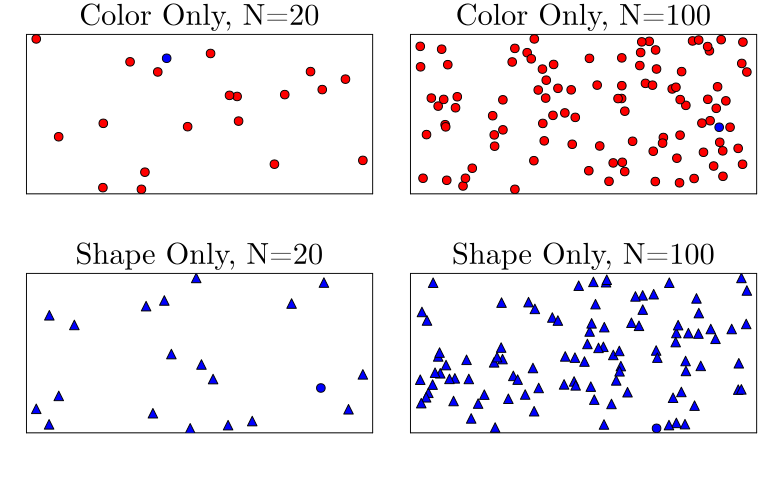

```julia
npt = 20
dist = Distributions.Product(Uniform.([0, 0], [1, 1]))
pts = Tuple.(eachcol(rand(dist, npt)))
blueidx = rand(1:npt)
p1 = scatter(pts[1:end .!= blueidx], color=:red, xticks=:false, yticks=:false, legend=:false, markersize=5, title="Color Only, N=20", framestyle=:box)
scatter!(p1, pts[blueidx, :], color=:blue, markersize=5)

npt = 100
pts = Tuple.(eachcol(rand(dist, npt)))
blueidx = rand(1:npt)
p2 = scatter(pts[1:end .!= blueidx], color=:red, xticks=:false, yticks=:false, legend=:false, markersize=5, title="Color Only, N=100", framestyle=:box)
scatter!(p2, pts[blueidx, :], color=:blue, markersize=5)

npt = 20
pts = Tuple.(eachcol(rand(dist, npt)))
blueidx = rand(1:npt)
p3 = scatter(pts[1:end .!= blueidx], color=:blue, markershape=:utriangle, xticks=:false, yticks=:false, legend=:false, markersize=5, title="Shape Only, N=20", framestyle=:box)
scatter!(p3, pts[blueidx, :], color=:blue, markersize=5, markershape=:circle)

npt = 100
pts = Tuple.(eachcol(rand(dist, npt)))
blueidx = rand(1:npt)
p4 = scatter(pts[1:end .!= blueidx], color=:blue, markershape=:utriangle, xticks=:false, yticks=:false, legend=:false, markersize=5, title="Shape Only, N=100", framestyle=:box)
scatter!(p4, pts[blueidx, :], color=:blue, markersize=5, markershape=:circle)

plot(p1, p2, p3, p4, layout=(2, 2), size=(800, 500))
```

## Color Schemes

Different color schemes are appropriate depending on whether the data is *sequential*, *divergent*, or *unordered*.

**Appropriate Color Schemes**

Color schemes should be *perceptually uniform* to preserve a mapping between changes in perceived colors and changes in attribute values.

Try to also choose color schemes which avoid confusing people who are color blind.

## Color Schemes

**Good news**: Most plotting libraries include a wide variety of perceptually uniform, color-blind safe color schemes.

**Bad news**: These are not usually the defaults (in particular, avoid “rainbow” color schemes).

## Sequential Color Schemes

Sequential schemes change in intensity from low to high as the value changes.

[figure not shown]

## Divergent Color Schemes

Divergent schemes intensify in two directions from a zero or mean value.

[figure not shown]

## Unordered Color Schemes

Unordered schemes are appropriate for categorical data.

[figure not shown]

## Some Caveats

- There is no recipe to effective visualization. Everything depends on your data and the story you want to tell.
- This also means that defaults from data visualization packages are usually bad.
- Principles are largely based on Western (American/European) norms and may not translate perfectly.
- A lot of these guidelines are based on average outcomes, there is likely to be a lot of individual variation.

# Key Points

## Probability Models

- Almost anything we want to use data for involves an assumption about the underlying probability model for the data.
- Our goal this semester is to develop a toolkit to specify, test, and use these probability models.

## EDA/Data Visualization

- No such thing as “objectively best” visualization.
- Need to be thoughtful about the story you’re trying to tell.
- Usually involves a lot of experimentation to make important features of the data pop out.
- **EDA**: Try to make as few assumptions as possible (e.g. look at the raw data, not “smoothed” versions).

## Data Visualization Suggestions

- Some key degrees of freedom: vertical scale, information channels.
- **Don’t add unnecessary artifacts!** Easy to get “cute” and distract from core message.
- Start simple (scatterplots, boxplots, histograms)

# Upcoming Schedule

## Next Classes

**Wednesday**: Linear Regression (Examples/Why It Works)

**Friday**: Data Visualization Lab (come prepared with a visualization and its underlying dataset).

## Assessments

**Homework 1** Due Friday, 2/6.

# References

## References (Scroll for Full List)

Hacking, I. (1990). *The Taming of Chance*. Cambridge, England: Cambridge University Press. https://doi.org/10.1017/CBO9780511819766

Healy, K. (2018). *Data visualization: A practical introduction*. Princeton University Press.

Munzner, T. (2014). *Visualization analysis and design*. CRC Press.